# One-sample t-toets

© 2020, SURF Versnellingsplan - Statistisch Handboek Hoger Onderwijs

Laatst gewijzigd op 11-01-2020

# 1 Toepassing

Gebruik de *one sample t-toets* om het gemiddelde van de steekproef te vergelijken met een bekend gemiddelde of norm van de totale populatie.[^1]

# 2 Onderwijscasus

De opleidingsdirecteur van de opleiding Werktuigbouwkunde wil weten of het gemiddelde eindexamencijfer voor de exacte vakken (Wiskunde, Natuurkunde en Scheikunde; WNS) van vwo studenten anders is dan het landelijk gemiddelde (6,8).[^2] Met deze gegevens probeert zij een inschatting te maken van het niveau van de studenten en kan zij bepalen of het curriculum van de inleidende vakken genoeg aansluit bij eerstejaars studenten met een vwo vooropleiding.

H<sub>0</sub>: Het gemiddelde eindexamencijfer voor de exacte vakken van vwo studenten die beginnen aan de Bachelor Werktuigbouwkunde is gelijk aan het landelijk gemiddelde: µ = 6,8.

H<sub>A</sub>: Het gemiddelde eindexamencijfer voor de exacte vakken van vwo studenten die beginnen aan de Bachelor Werktuigbouwkunde is anders dan het landelijk gemiddelde: µ ≠ 6,8.

# 3 Assumpties

Om een valide resultaat te bereiken moeten, voordat de toets kan worden uitgevoerd, de data aan een aantal voorwaarden voldoen.

## 3.1 Normaliteit

De *t-toets* gaat ervan uit dat de data van de steekproef normaal verdeeld zijn. Ga er bij een n > 100 vanuit dat de t-toets robuust genoeg is om uit te voeren zonder dat de data een normale verdeling volgen.[^3]

Controleer de assumptie van normaliteit met de volgende stappen:  
1. Controleer de data visueel met een histogram, een boxplot of een Q-Q plot.  
2. Toets of de data normaal verdeeld zijn met de *Kolmogorov-Smirnov test* of bij een kleinere steekproef (n < 50) met de *Shapiro-Wilk test*.[^4]<sup>,</sup>[^5]

Als blijkt dat de data niet normaal verdeeld zijn, transformeer de data eventueel en bepaal daarna of deze wel normaal verdeeld zijn.

Als er geen sprake is van normaliteit, gebruik de *Wilcoxon Signed Rank Test*.[^6][^7]

# 4 Uitvoering

Er is een dataset ingeladen met de gemiddelde eindexamencijfers van WNS van eerstejaars Werktuigbouwkunde: `Gemiddeld_cijfer_WNS` .

## 4.1 De data bekijken

Gebruik `head()` en `tail()` om de structuur van de data te bekijken.

```r
## Eerste 5 observaties
head(Gemiddeld_cijfer_WNS)
## [1] 7.400000 7.366667 7.366667 7.666667 5.933333 6.500000

## Laatste 5 observaties
tail(Gemiddeld_cijfer_WNS)
## [1] 6.333333 6.133333 8.066667 5.166667 7.700000 6.366667
```

Krijg meer inzicht in de dataset door het gemiddelde en de spreiding te bekijken, `length()`, `mean()` en `sd()` .

```r
## Gemiddelde en standaarddeviatie
length(Gemiddeld_cijfer_WNS)
## [1] 124
mean(Gemiddeld_cijfer_WNS)
## [1] 7.128763
sd(Gemiddeld_cijfer_WNS)
## [1] 0.7850378
```

- Gemiddeld cijfer WNS (standaardafwijking): 7,13 (0,79). *n* = 124.

## 4.2 Visuele inspectie van normaliteit

Geef normaliteit visueel weer met een histogram, Q-Q plot of boxplot.

### 4.2.1 Histogram

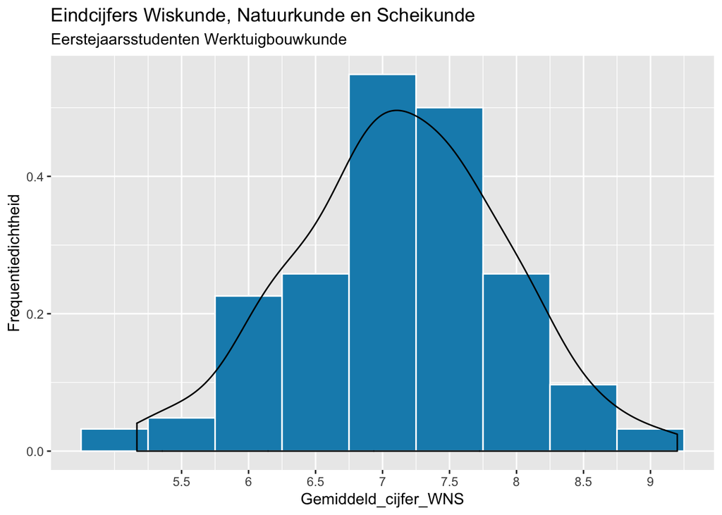

```r
## Histogram met ggplot2
library(ggplot2)

ggplot(data.frame(Gemiddeld_cijfer_WNS),
       aes(x = Gemiddeld_cijfer_WNS)) +
  geom_histogram(aes(y = ..density..),
                 binwidth = 0.5,
                 color = "white",
                 fill = "#158CBA", ) +
  geom_density(alpha = .2, adjust = 1) +
  ylab("Frequentiedichtheid") +
  xlab("Gemiddeld_cijfer_WNS") +
  scale_x_continuous(labels = as.character(seq(5.5, 9, 0.5)),
                     breaks = seq(5.5, 9, 0.5)) +
  labs(title = "Eindcijfers Wiskunde, Natuurkunde en Scheikunde",
       subtitle = "Eerstejaarsstudenten Werktuigbouwkunde")
```

Het histogram laat een Bell Curve zien vergelijkbaar met een normale verdeling: veel waardes liggen rondom het gemiddelde en weinig bij de staarten van de verdeling. Daarnaast ziet de verdeling er in grote mate symmetrisch uit.

### 4.2.2 Q-Q plot

Gebruik `qqnorm()` en `qqline()` met `pch = 1`om een Q-Q plot te maken, met als datapunten kleine cirkels.

Als over het algemeen de meeste datapunten op de lijn liggen, kan aangenomen worden dat de data normaal verdeeld zijn.

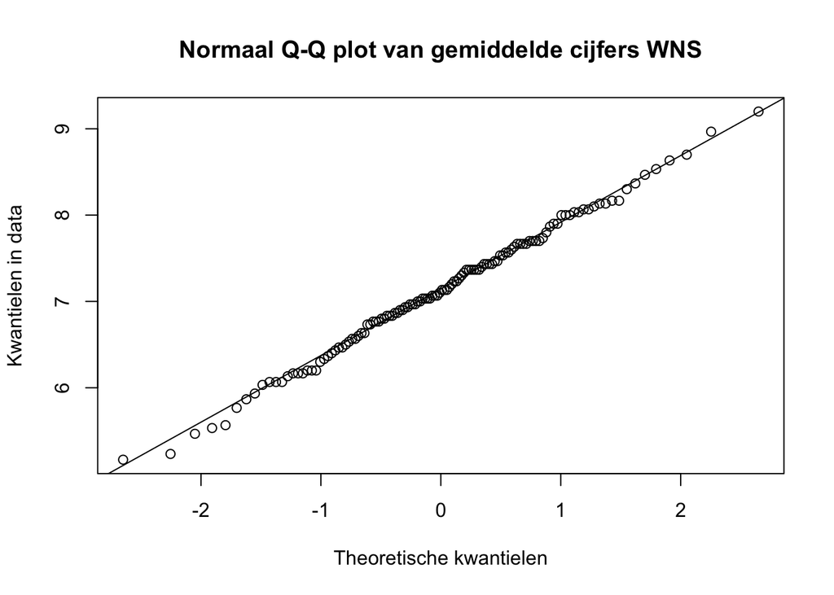

```r
## Q-Q plot
qqnorm(Gemiddeld_cijfer_WNS,
       pch = 1,
       main = "Normaal Q-Q plot van gemiddelde cijfers WNS",
       ylab = "Kwantielen in data",
       xlab = "Theoretische kwantielen")
qqline(Gemiddeld_cijfer_WNS)
```

In deze casus liggen de meeste punten op de lijn. Bij de uiteinden liggen de punten dichtbij de lijn.

### 4.2.3 Boxplot

De box geeft de middelste 50% van de tentamencijfers weer. De zwarte lijn binnen de box is de mediaan. In de staarten zitten de eerste 25% en de laatste 25%. Cirkels visualiseren mogelijke uitbijters.[^8]

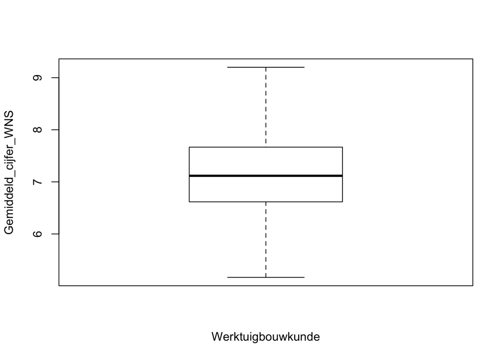

```r
## Boxplot
boxplot(Gemiddeld_cijfer_WNS, xlab = "Werktuigbouwkunde", ylab = "Gemiddeld_cijfer_WNS")
```

De boxplot geeft de spreiding van het gemiddelde eindexamencijfer voor de exacte vakken weer van de studenten Werktuigbouwkunde. De box en staarten zien er symmetrisch uit, wat een indicatie is van een normale verdeling.[^9]

## 4.3 Toetsen van normaliteit

Om te controleren of de data normaal verdeeld zijn, kan de normaliteit getoetst worden. Twee veelgebruikte toetsen zijn: de *Kolmogorov-Smirnov test* en de *Shapiro-Wilk test*.

### 4.3.1 Kolmogorov-Smirnov

De *Kolmogorov-Smirnov test* toetst het verschil tussen twee verdelingen. Standaard toetst deze test het verschil tussen een normale verdeling en de verdeling van de steekproef. De Lilliefors correctie wordt gebruikt als het gemiddelde niet 0 is en de standaardafwijking niet 1 is. Als de p < 0,05 is, is de verdeling van de data statistisch significant verschillend van de normale verdeling.

```r
## Kolmogorov-Smirnov test
library(nortest)
lillie.test(Gemiddeld_cijfer_WNS)
```

```
##
##  Lilliefors (Kolmogorov-Smirnov) normality test
##
## data:  Gemiddeld_cijfer_WNS
## D = 0.041104, p-value = 0.8745
```

De p-waarde is *p* > 0,05, dus er is geen statistisch significant verschil gevonden tussen de verdeling van de steekproef en de normale verdeling. De *one sample-t-toets* kan uitgevoerd worden.

### 4.3.2 Shapiro-Wilk Test

De *Shapiro-Wilk test* is een soortgelijke test als de *Kolmogorov-Smirnov test* en wordt vooral gebruikt bij kleine steekproeven (n < 50). Als de p < 0,05 is, is de verdeling van de data significant verschillend van de normale verdeling.

Er is een steekproef van `Gemiddeld_cijfer_WNS` ingeladen: `Gemiddeld_cijfer_WNS_n30`. De steekproef bevat 30 studenten.

```r
## Shapiro-Wilk test
shapiro.test(Gemiddeld_cijfer_WNS_n30)
```

```
##
##  Shapiro-Wilk normality test
##
## data:  Gemiddeld_cijfer_WNS_n30
## W = 0.98159, p-value = 0.866
```

De p-waarde is *p* > 0,05, dus er is geen statistisch significant verschil gevonden tussen de verdeling van de steekproef en de normale verdeling. De *one sample-t-toets* kan uitgevoerd worden.

## 4.4 One sample t-toets

Gebruik `t.test()`om een t-toets uit te voeren. Gebruik het argument `mu = 6.8` om het gemiddelde te specificeren waarmee wordt vergeleken en specifieer welke alternatieve hypothese er getoetst wordt. De verwachting is dat de studenten hoger scoren, maar omdat het relevant om te weten of de studenten ook lager scoren dan het landelijk gemiddelde is er voor gekozen om tweezijdig te toetsen. Gebruik hiervoor `alternative = "two.sided"`. Gebruik wederom de hele dataset `Gemiddeld_cijfer_WNS` met *n* = 124.

```r
## T-test
t.test(Gemiddeld_cijfer_WNS, mu = 6.8, alternative = "two.sided")
```

```
##
##  One Sample t-test
##
## data:  Gemiddeld_cijfer_WNS
## t = 4.6634, df = 123, p-value = 7.97e-06
## alternative hypothesis: true mean is not equal to 6.8
## 95 percent confidence interval:
##  6.989216 7.268311
## sample estimates:
## mean of x
##  7.128763
```

- Vrijheidsgraden, *df* = *n* -1 = 124-1 = 123
- *t* <sub>123</sub> = 4,66, *p* << 0,05
- p-waarde < 0,05, dus de H<sub>0</sub> wordt verworpen en de H<sub>A</sub> wordt aangenomen [^10]
- 95%-betrouwbaarheidsinterval: bij het herhalen van het onderzoek zal in 95% van de gevallen de µ in het interval vallen. In deze casus is het interval tussen 6,99 en 7,27.
- Het gemiddelde van de steekproef is 7,13

# 5 Rapportage

De *one sample t-toets* is uitgevoerd om te toetsen of het gemiddelde eindexamencijfer voor de exacte vakken van vwo studenten die Werktuigbouwkunde zijn gaan studeren anders is dan het landelijk gemiddelde. Het gemiddelde van de steekproef (*M* = 7,13, *SD* = 0,79) is statistisch significant hoger dan het landelijk gemiddelde van 6,8, *t* <sub>123</sub> = 4,66, *p* << 0,05.

De resultaten ondersteunen de conclusie dat het gemiddelde eindexamencijfer voor de exacte vakken van studenten Werktuigbouwkunde met een vwo vooropleiding hoger ligt dan het landelijk gemiddelde.

[^1]: Van Geloven, N. (25 mei 2016). *T-toets* [Wiki Statistiek Academisch Medisch Centrum](https://wikistatistiek.amc.nl/index.php/T-toets#one_sample_t-toets).
[^2]: Centraal Instituut voor Toetsontwikkeling (2018). *Examenverslag 2018*. https://www.cito.nl/onderwijs/voortgezet-onderwijs/centrale-examens-voortgezet-onderwijs/tools-en-informatie-voor-docenten/examenverslagen/examenverslag-2018
[^3]: Lumley, T., Diehr, P., Emerson, S., & Chen, L. (2002). The importance of the normality assumption in large public health data sets. Annu Rev Public Health, 23, 151-69. doi: 10.1146/annurev.publheath.23.100901.140546 http://rctdesign.org/techreports/arphnonnormality.pdf
[^4]: Laerd statistics (2018). [Testing for Normality using SPSS Statistics](https://statistics.laerd.com/spss-tutorials/testing-for-normality-using-spss-statistics.php).
[^5]: Normaliteit. (14 juli 2014). [UvA Wiki Methodologiewinkel](https://wiki.uva.nl/methodologiewinkel/index.php/Normaliteit).
[^6]: De *Wilcoxon signed rank toets* maakt een rangschikking van de data. Hierdoor is de test verdelingsvrij en is normaliteit geen assumptie. Ook zijn uitbijters minder van invloed op het eindresultaat. Toch wordt er voor deze test minder vaak gekozen, dit komt doordat bij het maken van een rankschikking de data informatie verliest. Als de data wel normaal verdeeld zijn heeft de *Wilcoxon signed rank toets* minder onderscheidend vermogen, dan wanneer de *one sample t-toets* uitgevoerd zou worden.
[^7]: Prabhakaran, S. (2016-2017). *Statistical Tests*. http://r-statistics.co/Statistical-Tests-in-R.html
[^8]: Outliers (13 augustus 2016). [UvA Wiki Methodologiewinkel](https://wiki.uva.nl/methodologiewinkel/index.php/Outliers).
[^9]: Uitbijters kunnen bepalend zijn voor de uitkomst van toetsen. Bekijk of de uitbijters valide uitbijters zijn en niet een meetfout of op een andere manier incorrect verkregen data. Het weghalen van uitbijters kan de uitkomst ook vertekenen, daarom is het belangrijk om verwijderde uitbijters te melden in een rapport.
[^10]: In dit voorbeeld wordt uitgegaan van een waarschijnlijkheid van 95% en c.q. een p-waardegrens van 0,05. De grens is naar eigen inzicht aan te passen, hou hierbij rekening met type I en type II fouten.